# Characterizing Automobiles

Author

Cameron Hayman

Published

March 21, 2025

# Setup

- Setup

```r
sh <- suppressPackageStartupMessages
sh(library(tidyverse))
sh(library(caret))
sh(library(fastDummies))
sh(library(class))
sh(library(ISLR)) # for the "Auto" dataframe
library(pROC)
```

# Dataframe

- We use the `Auto` dataframe.

```r
head(Auto)
```

```
  mpg cylinders displacement horsepower weight acceleration year origin
1  18         8          307        130   3504         12.0   70      1
2  15         8          350        165   3693         11.5   70      1
3  18         8          318        150   3436         11.0   70      1
4  16         8          304        150   3433         12.0   70      1
5  17         8          302        140   3449         10.5   70      1
6  15         8          429        198   4341         10.0   70      1
                       name
1 chevrolet chevelle malibu
2         buick skylark 320
3        plymouth satellite
4             amc rebel sst
5               ford torino
6          ford galaxie 500
```

- It has the following variable names, which describe various attributes of automobiles.

```r
names(Auto)
```

```
[1] "mpg"          "cylinders"    "displacement" "horsepower"   "weight"
[6] "acceleration" "year"         "origin"       "name"
```

# Multiple Regression

- Run a linear regression model with `mpg` as the dependent variable and `horsepower` and `year` as features (variables).
- Compute and comment on the RMSE.

### Regression Model

```r
model <- lm(mpg ~ horsepower + year, data = Auto)
preds <- predict(model, newdata = Auto)
rmse <- RMSE(preds, Auto$mpg)
```

### Model Summary

```r
summary(model)
```

```
Call:
lm(formula = mpg ~ horsepower + year, data = Auto)

Residuals:
     Min       1Q   Median       3Q      Max
-12.0768  -3.0783  -0.4308   2.5884  15.3153

Coefficients:
              Estimate Std. Error t value Pr(>|t|)
(Intercept) -12.739166   5.349027  -2.382   0.0177 *
horsepower   -0.131654   0.006341 -20.761   <2e-16 ***
year          0.657268   0.066262   9.919   <2e-16 ***
---
Signif. codes:  0 '***' 0.001 '**' 0.01 '*' 0.05 '.' 0.1 ' ' 1

Residual standard error: 4.388 on 389 degrees of freedom
Multiple R-squared:  0.6855,    Adjusted R-squared:  0.6839
F-statistic: 423.9 on 2 and 389 DF,  p-value: < 2.2e-16
```

### RMSE

```r
rmse
```

```
[1] 4.371506
```

> TODO: *With an RMSE of 4.37, it can be inferred that the linear regression model can accurately predict the mpg of a vehicle within a standard error of 4.5 mpg using only the year and the horsepower of the car as features within the model.*

# Feature Engineering

- Create 10 features based on the `name` column.
- Remove all rows with a missing value.
- Ensure only `mpg` and the engineered features remain.
- Compute and comment on the RMSE.

### Names of all cars

```r
#Generated unique names to look at the various brands of cars to see if i could group by location
#unique(Auto$name)
```

```r
auto_features <- Auto %>%
  mutate(
    name_lower = tolower(name),
    brand = word(name_lower, 1),
    is_japanese = str_detect(name_lower, "honda|toyota|datsun|mazda|subaru"),
    is_american = str_detect(name_lower, "ford|chevrolet|chevy|buick|plymouth|dodge"),
    is_european = str_detect(name_lower, "volkswagen|fiat|audi|bmw|peugeot|renault|opel|mercedes"),
    is_truck = str_detect(name_lower, "pickup|truck"),
    is_wagon = str_detect(name_lower, "wagon"),
    is_sedan = str_detect(name_lower, "sedan"),
    is_van = str_detect(name_lower, "van"),
    contains_sport = str_detect(name_lower, "sport"),
    has_deluxe = str_detect(name_lower, "deluxe"),
    contains_limited = str_detect(name_lower, "limited"),
  ) %>%
  drop_na() %>%
  select(mpg, is_japanese, is_american, is_european, is_truck, is_wagon, is_sedan, is_van, contains_sport, has_deluxe,
         contains_limited)

# Train/test split
set.seed(505)
split <- createDataPartition(auto_features$mpg, p = 0.8, list = FALSE)
train <- auto_features[split, ]
test <- auto_features[-split, ]

fe_model <- lm(mpg ~ ., data = train)
fe_preds <- predict(fe_model, newdata = test)
rmse_fe <- RMSE(fe_preds, test$mpg)
rmse_fe
```

```
[1] 6.548358
```

# Classification

- Use either of $K$-NN or Naive Bayes to predict whether an automobile is a `chevrolet` or a `honda`.
- Explain your choice of technique.
- Report on your Kappa value.

### Generating Chevrolet and Honda brands

```r
auto_class <- Auto %>%
  mutate(brand = word(name, 1)) %>%
  filter(brand %in% c("chevrolet", "honda")) %>%
  mutate(brand = factor(brand)) %>%
  select(mpg, horsepower, weight, year, brand) %>%
  drop_na()
```

### Splitting The Data

```r
set.seed(505)
split_class <- createDataPartition(auto_class$brand, p = 0.8, list = FALSE)
train_class <- auto_class[split_class, ]
test_class <- auto_class[-split_class, ]
```

### Running The Model

```r
ctrl <- trainControl(method = "cv", number = 10)
model_class <- train(
  brand ~ .,
  data = train_class,
  method = "knn",
  tuneGrid = expand.grid(k = 3),
  trControl = ctrl
)
```

### Confusion Matrix & Kappa Value

```r
pred_class <- predict(model_class, newdata = test_class)
conf_class <- confusionMatrix(pred_class, test_class$brand)
conf_class$overall["Kappa"]
```

```
    Kappa
0.6153846
```

# Binary Classification

- Predict whether a car is a `honda`.
- Use model weights.
- Display and comment on an ROC curve.

```r
auto_binary <- Auto %>%
  mutate(honda = as.factor(word(name, 1) == "honda")) %>%
  select(mpg, horsepower, weight, year, honda) %>%
  drop_na()
```

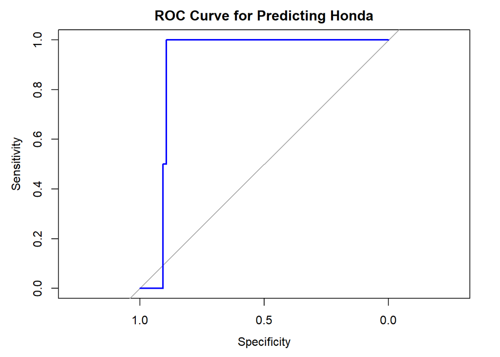

```r
set.seed(505)
split <- createDataPartition(auto_binary$honda, p = 0.8, list = FALSE)  # Fix: use auto_binary
train <- auto_binary[split, ]
test <- auto_binary[-split, ]

bin_model <- glm(honda ~ ., data = train, family = binomial)
bin_probs <- predict(bin_model, test, type = "response")

roc_obj <- roc(as.numeric(test$honda) - 1, bin_probs)
plot(roc_obj, col = "blue", main = "ROC Curve for Predicting Honda")
```

```r
#auc(roc_obj)
```

> TODO: *This ROC curve maps the mdoels ability to accurately classify whether the car is a honda or not. This model demonstrates a strong true positive rate, but struggles slightly with specificity. With an AUC of 0.9 however, we can see that the model is fairly accurate at predicting the class of honda vehicles compared to others.*

# Ethics

- Based on your analysis, comment on the [Clean Air Act of 1970 and Ammendments of 1977](https://www.epa.gov/clean-air-act-overview/evolution-clean-air-act)
- Discuss the civic reposibilities of data scientists for:
  - Big Data and Human-Centered Computing
  - Democratic Institutions
  - Climate Change
- Provide at least one statistical measure for each, such as a RMSE, Kappa value, or ROC curve.

> TODO: Big Data and Human-Centered Computing

```r
#rmse_reg
```

> TODO: *RMSE is used to measure the average error in a regression model. This makes it useful for assessing prediction accuracy in big data applications where error minimization improves human decision-making. The example RMSE of 4.37 suggests the magnitude of the model’s prediction error in a continuous outcome when it comes to things like: estimating emissions, economic indicators, or social impact metrics.*

> TODO: Democratic Institutions

```r
#conf_class$overall["Kappa"]
```

> TODO: *The Kappa statistic measures the agreement between the model’s predictions and actual labels, adjusted for random chance. As for democratic institutions, it evaluates how well a classification model can predict things like political outcomes or voter behaviors beyond random chance.*

> TODO: Climate Change

```r
roc_bin <- roc(as.numeric(test$honda) - 1, bin_probs)
auc(roc_bin)
```

```
Area under the curve: 0.9
```

> TODO: *AUC quantifies the bias within a binary classifier, indicating how well the model can distinguish between two classifications. This can be used in predicting climate change risks or sustainability compliance. A higher AUC suggests that the model effectively differentiates between climate-positive and climate-negative cases, which could be used to aid policymakers in their decision-making.*